# Multi-Input and Multi-Output Neural Network Shapley Values with Keras, R, and Python

Nick Redell, nickredell@hotmail.com

2019-01-01

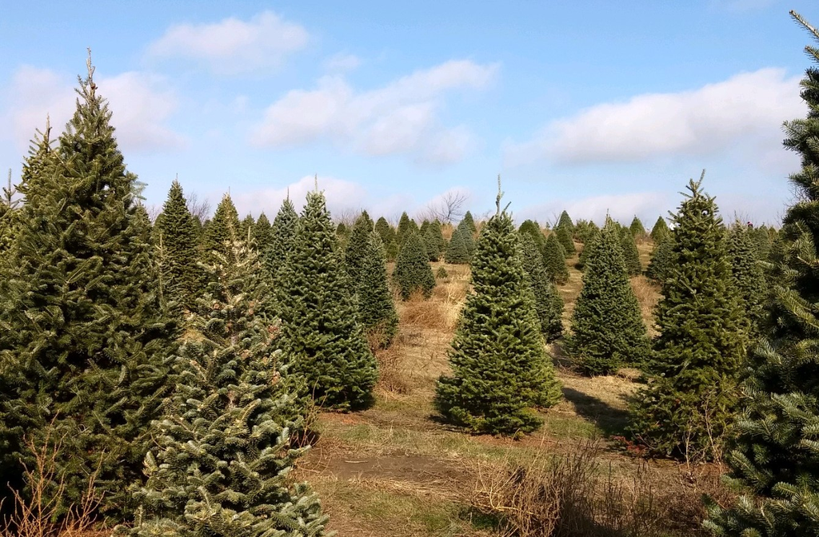

As algorithmic decision-making continues its headlong rush into our everyday lives, interpretable machine learning has become increasingly relevant for society, machine/deep learning researchers, and data science practicioners alike ([1](https://arxiv.org/abs/1702.08608)). And while numerous statistical techniques and methodologies have been dedicated to making black-box models and the decisions that they produce more human-friendly, one method in particular, the Shapley value, has a number of desirable properties including its ability to unify several seemingly different methodologies ([2](http://papers.nips.cc/paper/7062-a-unified-approach-to-interpreting-model-predictions.pdf)).

Briefly, in the context of machine learning, a Shapley value represents the marginal or unique contribution of each model feature toward each prediction. It’s a **hyper-local measure of feature importance** for each individual or instance which gives a clear profile of how a prediction model is uniquely making predictions for a given instance. Shapley values are measured in the same units in which your model is making predictions: dollars, number of cats, risk, probability etc. The Shapley method of feature influence has a number of practical applications which include (a) detecting bias in machine learning models, (b) training and tuning models by assessing the Shapley values of influential observations, and (c) using the resulting ‘instance * feature’ matrix as an input for a variety of additional machine learning tasks such as clustering.

Below are several good resources to learn more about the features, benefits, and uses of Shapley values for interpreting black-box machine learning models:

- [Interpretable Machine Learning by Christoph Molnar](https://christophm.github.io/interpretable-ml-book/shapley.html)
- [Python shap package by Scott Lundberg](https://github.com/slundberg/shap)
- [Blog post from the author of shap](https://towardsdatascience.com/interpretable-machine-learning-with-xgboost-9ec80d148d27)

## Problem

Fortunately, for the applied data scientist there exists two great packages– [iml](https://cran.r-project.org/web/packages/iml/index.html) for `R` and shap for `Python`–which give model-agnostic (R and Python) and model-specific (Python) methods for calculating Shapley values. Unfortunately, getting these packages to work with less common multi-task or multi-outcome machine learning problems ([3](https://arxiv.org/pdf/1707.08114.pdf)) is not entirely straigtforward or, in the case of `shap`, apparently possible yet. Here, multi-outcome refers to a model making 2 or more simultaneous predictions per instance (think of 2 ‘y’ columns in the X, y paradigm). The purpose of this post is to demonstrate how to calculate and interpret Shapley values in each language by going step-by-step through an applied multi-outcome machine learning problem.

## Goals of this Tutorial

- Apply the R package `iml` to obtain Shapley values for a multi-outcome machine learning problem.
- Write a Python function(s) that mimics R’s `iml::Shapley()` and apply it to the same problem.
- Visualize and interpret the models’ Shapley values in the context of a multi-outcome problem.

## Tutorial Setup

### Data

The dataset used in this tutorial is the solar flair dataset available from the [UCI Machine Learning Repository](http://archive.ics.uci.edu/ml/datasets/Solar+Flare). A description of the dataset columns–10 features and 3 outcomes–is available below (copied from the link). With only 10 features, this dataset is well suited for this tutorial because the `iml::Shapley()` and custom Python function presented here are brute force approaches that approximate the computationally expensive Shapley value through random sampling–fewer features giving better approximations at a given sample size. It’s worth mentioning that `shap` does implement computationally efficient and exact Shapley value functions for several popular boosted tree packages.

#### Features

1. Code for class (modified Zurich class) (A,B,C,D,E,F,H)
2. Code for largest spot size (X,R,S,A,H,K)
3. Code for spot distribution (X,O,I,C)
4. Activity (1 = reduced, 2 = unchanged)
5. Evolution (1 = decay, 2 = no growth, 3 = growth)
6. Previous 24 hour flare activity code (1 = nothing as big as an M1, 2 = one M1, 3 = more activity than one M1)
7. Historically-complex (1 = Yes, 2 = No)
8. Did region become historically complex on this pass across the sun’s disk (1 = yes, 2 = no)
9. Area (1 = small, 2 = large)
10. Area of the largest spot (1 = <=5, 2 = >5)

#### Outcomes

11. C-class flares production by this region in the following 24 hours (common flares); Number
12. M-class flares production by this region in the following 24 hours (moderate flares); Number
13. X-class flares production by this region in the following 24 hours (severe flares); Number

### Model

#### Multi-output

We’ll build the same neural network multi-output machine learning models in R and Python using [Keras](https://keras.io/). While multi-outcome problems can simply be turned into multiple single outcome problems or estimated in their original multi-outcome format with somewhat elaborate frameworks ([4](https://arxiv.org/pdf/1211.6581.pdf)), a single neural network (a) allows the data scientist to improve model accuracy by taking advantage of the possibly correlated outcomes and (b) is likely more maintainable in a production environment.

The outcomes are represent counts so a Poisson or similar distribution would be ideal for our model. In this tutorial we’ll simply use a linear loss as if we were performing 3 simultaneous linear regressions.

#### Multi-input

Multi-input? Wait, isn’t there just a single dataset for model building and prediction? Yes. The need to define this problem as multi-input lies in (a) our wanting **interpretable Shapley values for categorical predictors** and (b) the data input format for Keras. Regarding interpretable categorical feature effects, traditional dummy coding or one-hot encoding, which turns a single categorical feature into multiple categorical features with one feature per category, would make our Shapley value feature exaplanations more difficult to reason about. And the problem of feature effect [un]interpretability increases with higher cardinality features such as zip code or SKUs.

An arguably better approach in the context of neural networks involves passing each categorical feature–especially features with many categories–through an embedding layer. In Keras, the categorical feature transformations needed for the embedding layer happen behind the scenes. This makes our lives easier because, with one un-transformed categorical feature going into the model for prediction, it will allow us to easily reason about the effects of that feature in the model. The byproduct of of this setup is that we’ve gone from one input, our original dataset, to **1 input per categorical feature** and **1 input for the rest of our numeric predictors**. We’ll have to account for these multiple inputs in our `iml::Shapley()` and Python functions.

You can read more about categorical feature embeddings in the [TensorFlow guide](https://www.tensorflow.org/guide/embedding).

## Tutorial - R

- In the R walkthrough we’ll focus on the steps need to obtain multi-outcome Shapley values from one Keras model. Our goal isn’t to build the most accurate model.
- We’ll also use RStudio’s reticulate package which lets us use R and Python code chunks within the same R notebook. Note that you need to have the current preview version of RStudio installed (v1.2+) to pass objects between the R and Python environments. Here, `reticulate` is mostly used to pass Python DataFrames to R for plotting.

### Environment setup

```r
library(farff)  # load .arff file
library(dplyr)  # data manipulation
library(stringr)  # string manipulation
library(keras)  # neural netowrk model
library(ggplot2)  # plotting
library(reticulate)  # working w/ R and Python together in Rmarkdown

# Use a specific version of Python. Probably not needed if Python is in your R PATH.
reticulate::use_python(".../Continuum/anaconda3/python.exe")

#setwd("/user/working_directory/data")
```

### Load data

- The solar flare data was saved and loaded locally from ./data/.

```r
data <- farff::readARFF("data/sf2.arff", data.reader = "readr",
                        convert.to.logicals = TRUE, show.info = FALSE)
data <- tibble::as_tibble(data)
data
```

| mod_zurich_class | largest_spot_size | spot_distribution | activity | evolution | previous_day_activity | hist_complex | become_hist_complex | area | area_largest | c-class | m-class | x-class |
| --- | --- | --- | --- | --- | --- | --- | --- | --- | --- | --- | --- | --- |
| H | A | X | 1 | 3 | 1 | 1 | 1 | 1 | 1 | 0 | 0 | 0 |
| D | R | O | 1 | 3 | 1 | 1 | 2 | 1 | 1 | 0 | 0 | 0 |
| C | S | O | 1 | 3 | 1 | 1 | 2 | 1 | 1 | 0 | 0 | 0 |
| H | R | X | 1 | 2 | 1 | 1 | 1 | 1 | 1 | 0 | 0 | 0 |
| H | S | X | 1 | 1 | 1 | 1 | 2 | 1 | 1 | 0 | 0 | 0 |
| C | A | O | 1 | 2 | 1 | 1 | 2 | 1 | 1 | 0 | 0 | 0 |
| B | X | O | 1 | 3 | 1 | 1 | 2 | 1 | 1 | 0 | 0 | 0 |
| C | A | O | 1 | 3 | 1 | 1 | 2 | 1 | 1 | 0 | 0 | 0 |
| C | A | O | 1 | 2 | 1 | 1 | 2 | 1 | 1 | 1 | 0 | 0 |
| B | X | O | 1 | 3 | 1 | 1 | 2 | 1 | 1 | 0 | 0 | 0 |

[output cut: 990 more lines]

### Data preparation

- While each of the 10 predictors appear to be either categorical or ordinal, we’ll treat the ordinal `previous_day_activity`, which takes on the values of 1 through 3, as continuous for the sake of illustration.
- If you’re unsure of what `!!` is doing in the `dplyr` functions, go [here](https://dplyr.tidyverse.org/articles/programming.html) to learn more about non-standard evaluation and quosures with `dplyr`.

```r
categorical_features <- names(data)[-c(6, 11:13)]
numeric_features <- names(data)[6]
outcome_names <- names(data)[11:13]
n_outcomes <- length(outcome_names)  # our 3 outcomes

data[, numeric_features][] <- lapply(data[, numeric_features], as.double)
data[, outcome_names][] <- lapply(data[, outcome_names], as.double)

data <- data %>%
  # Subtracting 1 because Keras/TensorFlow like factors to start at 0.
  dplyr::mutate_if(!!names(data) %in% categorical_features, function(x) {
    as.double(as.factor(x)) - 1}) %>%
  dplyr::mutate_if(!!names(data) %in% numeric_features, function(x) {
    (x - mean(x, na.rm = TRUE)) / sd(x, na.rm = TRUE)})
# Subtracting another 1 from mod_zurich_class because the first level, A,
# does not appear in the dataset.
data$mod_zurich_class <- data$mod_zurich_class - 1
```

- Create separate datasets for Keras inputs.

```r
X_model_cat <- dplyr::select(data, !!categorical_features)
X_model_num <- dplyr::select(data, !!numeric_features)
y_model <- dplyr::select(data, !!outcome_names)
```

### Keras neural network

- Loop through the categorical features and save the Keras (a) input layers and (b) embedding output layers in separate lists.
- Notice that `keras::layer_input()` has a shape of 1 for 1 categorical feature.
- Credit for categorical feature entity embedding inspiration goes [here](https://github.com/entron/entity-embedding-rossmann) and [here](https://arxiv.org/pdf/1604.06737.pdf) for the code and paper, respectively.

```r
layers_input_cat <- vector("list", length(categorical_features))
layers_output_cat <- vector("list", length(categorical_features))
for (i in seq_along(layers_input_cat)) {
  categorical_feature <- categorical_features[i]
  layers_input_cat[[i]] <- keras::layer_input(shape = c(1),
                                              name = paste0("input_", categorical_feature))
  no_of_unique_cat <- length(unlist(unique(X_model_cat[, categorical_features[i]])))
  embedding_dim <- as.integer(min(ceiling((no_of_unique_cat) / 2), 50))

  layers_output_cat[[i]] <- layers_input_cat[[i]] %>%
    keras::layer_embedding(no_of_unique_cat, embedding_dim, input_length = 1,
                           name = paste0("embedding_", categorical_feature)) %>%
    keras::layer_reshape(target_shape = (embedding_dim),
                         name = paste0("reshape_", categorical_feature))
}
```

- Create a separate input layer for the dataset of numeric predictors.

```r
layers_input_num <- keras::layer_input(shape = c(ncol(X_model_num)),
                                       name = "input_numeric_features")

layers_output_num <- layers_input_num %>%
  keras::layer_dense(1, activation = "relu")
```

- Concatenate the list of categorical embedding layers and numeric layers.
- Build a dense network on top of these layers that will model our 3 outcomes.
- Compile the model.

```r
layers_concat <- keras::layer_concatenate(c(layers_output_cat, layers_output_num))

layers_output_all <- layers_concat %>%
  keras::layer_dense(as.integer((length(categorical_features) + length(numeric_features)) / 2),
                     activation = "relu") %>%
  keras::layer_dense(n_outcomes)  # our 3 outcomes.

model <- keras::keras_model(inputs = c(layers_input_cat, layers_input_num),
                            outputs = c(layers_output_all))

model <- model %>% keras::compile(
  optimizer = 'rmsprop',
  loss = 'mean_squared_error'
)
```

- Prepare the categorical data by creating a list of vectors, 1 for each feature.
- Place the data for the numeric feature(s) and model outcomes into separate lists.
- Fit the model…but do a better job than I’m doing here.

```r
X_model_cat_input <- vector("list", length(categorical_features))
for (i in seq_along(X_model_cat_input)) {
  X_model_cat_input[[i]] <- as.matrix(X_model_cat[, i])
}
X_model_num_input <- list(as.matrix(X_model_num))
y_model_input <- list(as.matrix(y_model))

set.seed(224)
model_results <- model %>% keras::fit(x = c(X_model_cat_input, X_model_num_input),
                                      y = y_model_input, epochs = 100, verbose = FALSE)
```

### Model prediction

- Generate predictions from the model and plot the actuals vs. the predictions.
- Our model’s predictions are less than stellar. Ideally, the points would fall along the blue line where the predictions equal the actuals, but we can see that we’re severly underpredicting across all outcomes. In the real world this model would need to be improved before we even consider interpreting the feature effects, but we’ll continue to press on and see what the Shapley values have to say.

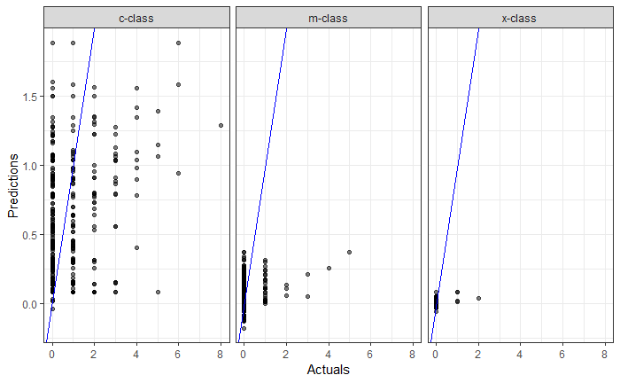

```r
y_pred <- tibble::as.tibble(predict(model, c(X_model_cat_input, X_model_num_input)))
names(y_pred) <- outcome_names
y_pred <- tibble::as.tibble(data.table::melt(y_pred))
names(y_pred) <- c("outcome", "y_pred")

y_actual <- y_model
y_actual <- tibble::as.tibble(data.table::melt(y_actual))
y_actual <- y_actual[, -1]
names(y_actual) <- "y_actual"

data_plot <- dplyr::bind_cols(y_pred, y_actual)

p <- ggplot(data_plot, aes(y_actual, y_pred))
p <- p + geom_point(alpha = .5)
p <- p + geom_abline(color = "blue")
p <- p + facet_wrap(~ outcome)
p <- p + theme_bw() + xlab("Actuals") + ylab("Predictions")
p
```

### Shapley values

#### Custom prediction function

- Below is our custom prediction function that the `iml` package will use to prepare the input dataset for our multi-input, multi-output Keras model which is then used to compute Shapley values for each instance and feature in the dataset.
- The specifics may change here as this package is under fairly active development, but at present the `iml::Predictor$new()` instantiation of the class that `iml::Shapley()` inherits from only takes the 2 required arguments below. Because of this, we’re going to use `categorical_features` and `numeric_features` as defined in the global environment. This isn’t ideal but it’ll work for the problem at hand.

```r
# The second argument must be 'newdata'.
prediction_function <- function(model, newdata) {
  data_x <- as.data.frame(newdata)
  X_model_cat <- data_x[, categorical_features]  # defined in the global env.
  X_model_num <- data_x[, numeric_features]  # defined in the global env.
  X_model_num_input <- list(as.matrix(X_model_num))

  X_model_cat_input <- vector("list", length(categorical_features))
  for (i in seq_along(X_model_cat_input)) {
    X_model_cat_input[[i]] <- as.matrix(X_model_cat[, i])
  }
  return(as.data.frame(predict(model, c(X_model_cat_input, X_model_num_input))))
}
```

#### Compute Shapley values

- With our model and custom `iml` prediction function ready, let’s prepare the input dataset for `iml::Shapley()`.
  - First, because we’re using a computationally intensive approach to compute Shapley values, we’ll filter our dataset to only explain the 201 instances with 1 or more positive counts across the 3 outcomes.
  - Next, we’ll drop the outcome columns from our dataset so that they won’t appear in our Shapley results table.
- Now we’ll loop through our filtered dataset, computing Shapley values for one instance at a time and saving the results table to a list.
- The code below takes about 4 minutes to run on an Intel i7 laptop with 16GB of RAM.

```r
data_shap <- as.data.frame(data)
# Filter to select instances with 1 or more positive outcomes.
data_shap <- data_shap[rowSums(data_shap[, outcome_names]) > 0, ]
# Remove the outcome names
data_shap <- data_shap[, !names(data_shap) %in% outcome_names]

# Instantiate the iml::Predictor class for iml::Shapley().
predictor <- iml::Predictor$new(model, data = data_shap, predict.fun = prediction_function)

# Loop through the samples, explaining one instance at a time.
shap_values <- vector("list", nrow(data_shap))
system.time({
  for (i in seq_along(shap_values)) {
    set.seed(224)
    shap_values[[i]] <- iml::Shapley$new(predictor, x.interest = data_shap[i, ],
                                         sample.size = 100)$results
    shap_values[[i]]$sample_num <- i
  }
  data_shap_values <- dplyr::bind_rows(shap_values)
})
```

#### Plot feature effects

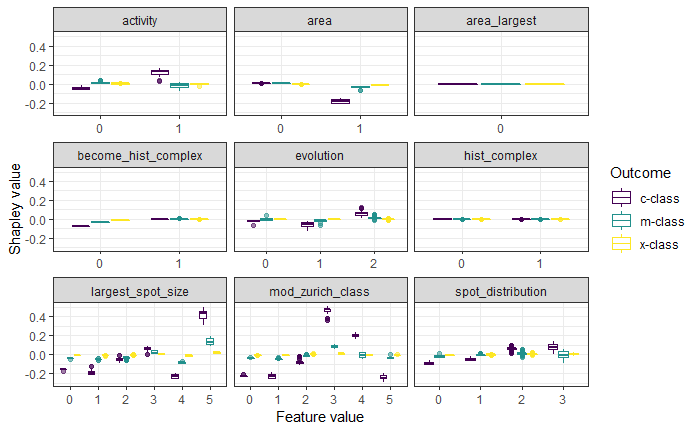

```r
# Use a substring search to get the values of each feature for each instance
# for the quasi-partial dependence plots.
data_shap_values$feature_value <- substr(data_shap_values$feature.value,
                                         stringr::str_locate(data_shap_values$feature.value, "=")[, 1] + 1,
                                         nchar(data_shap_values$feature.value))
data_shap_values$feature_value <- as.numeric(data_shap_values$feature_value)
data_shap_values$outcome <- factor(data_shap_values$class, labels = outcome_names)

data_shap_cat <- data_shap_values[data_shap_values$feature %in% categorical_features, ]
data_shap_num <- data_shap_values[data_shap_values$feature %in% numeric_features, ]

# The outcome is referred to as 'class' in our iml::Shapley() output.
p <- ggplot(data_shap_cat, aes(x = factor(feature_value), y = phi, color = outcome))
p <- p + geom_boxplot(alpha = .50)
p <- p + scale_colour_viridis_d()
p <- p + facet_wrap(~ feature, scales = "free_x")
p <- p + theme_bw() + xlab("Feature value") + ylab("Shapley value") + labs(color = "Outcome")
p
```

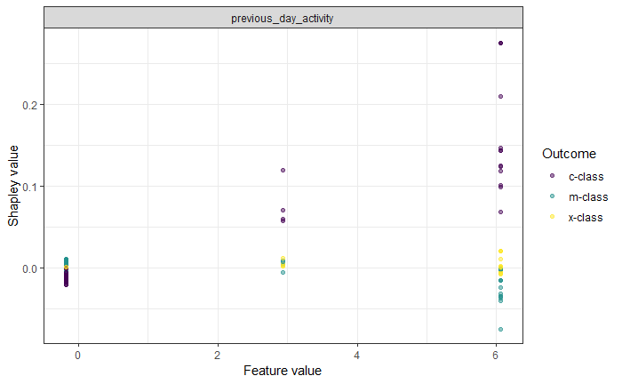

```r
p <- ggplot(data_shap_num, aes(x = round(as.numeric(feature_value), 2), y = phi,
                               color = outcome))
p <- p + geom_point(alpha = .50)
p <- p + scale_colour_viridis_d()
p <- p + facet_wrap(~ feature)
p <- p + theme_bw() + xlab("Feature value") + ylab("Shapley value") + labs(color = "Outcome")
p
```

- **Local feature importance:** Let’s plot the Shapley values for a single instance in the dataset. This plot shows an individualized feature effect profile and would be unique for each instance in our dataset.
- **Interpretation:**
  - For this instance, the red bars represent a feature that decreased the model’s predictions relative to the average prediction for each outcome (the average prediction has been centered at 0). Blue bars represent a feature that increased the predicted number of solar flares.
  - If our sample size was large enough (or if we were using [an exact method for calculating Shapley values](https://arxiv.org/abs/1802.03888)), for each outcome we could simply sum the positive and negative Shapley values for each feature and add the result to the average prediction for each outcome and arrive at the same predicted value that we get from our `predict()` function.

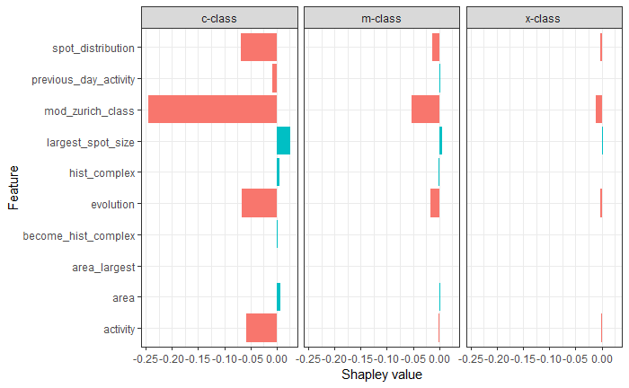

```r
data_plot <- data_shap_values
data_plot <- dplyr::filter(data_plot, sample_num == 1)

data_plot$bar_color <- ifelse(data_plot$phi >= 0, "increase", "decrease")

p <- ggplot(data_plot, aes(x = feature, y = phi, fill = bar_color, group = sample_num))
p <- p + geom_bar(stat = "identity", show.legend = FALSE)
p <- p + facet_wrap(~ outcome)
p <- p + theme_bw() + coord_flip() + xlab("Feature") + ylab("Shapley value")
p
```

## Tutorial - Python

- The Python tutorial will mimic the R tutorial nearly line for line with the exception of the Shapley value calculations. Calculating Shapley values in R was fairly straightforward thanks to the `iml` package; however, I was unable to find a Python equivalent that would handle our multi-input, multi-ouput problem. So we’ll create two custom functions, `shap_feature_effects()` and `shap_summary()`, that are inspired by the `iml` source code.
- The goal with `shap_feature_effects()` and `shap_summary()` was to, as closely as possible, mirror the `iml::Shapley()` function, giving a similar output but without the supporting class methods and error handling under the hood. The interested reader is more than welcome to modify this code as they see fit.

### Environment setup

```python
import os
from timeit import default_timer as timer
import copy
from scipy.io import arff
import random
import numpy as np
import pandas as pd
from sklearn.preprocessing import StandardScaler
from keras.models import Sequential, Model
from keras.layers import Input, Embedding, Reshape, Dense, Concatenate

#os.chdir("/user/working_directory/data")
```

### Load data

- The solar flare data was saved and loaded locally from ./data/.

[output not shown]

### Data preparation

- While each of the 10 predictors is either categorical or ordinal, we’ll treat the ordinal `previous_day_activity`, which takes on the values of 1 through 3, as continuous for the sake of illustration.

```python
categorical_features = data.columns[0:10].tolist()
categorical_features.pop(5)
numeric_features = [data.columns[5]]
outcome_names = data.columns[10:].tolist()
n_outcomes = len(outcome_names)

data.loc[:, categorical_features] = data.loc[:, categorical_features].apply(lambda x: pd.factorize(x)[0])

X_scaler = StandardScaler()
data.loc[:, numeric_features] = data.loc[:, numeric_features].astype('float32')
data.loc[:, numeric_features] = X_scaler.fit_transform(data[numeric_features])

data.loc[:, outcome_names] = data.loc[:, outcome_names].astype('float32')
```

- Create separate datasets for Keras inputs.

```python
X_model_cat = data[categorical_features].values
X_model_num = data[numeric_features].values
y_model = data[outcome_names].values
```

### Keras neural network

- Loop through the categorical features and save the Keras (a) input layers and (b) embedding output layers in separate lists.
- Notice that keras::layer_input() has a shape of 1 for 1 categorical feature.
- Credit for categorical feature entity embedding inspiration goes [here](https://github.com/entron/entity-embedding-rossmann) and [here](https://arxiv.org/pdf/1604.06737.pdf) for the code and paper, respectively.

```python
layers_input_cat = [[None] for _ in range(len(categorical_features))]
layers_output_cat = [[None] for _ in range(len(categorical_features))]
for i in range(len(categorical_features)) :
    categorical_feature = categorical_features[i]
    layers_input_cat[i] = Input(shape = (1, ), name = "input_" + categorical_feature)
    no_of_unique_cat = data[categorical_feature].nunique()
    embedding_dim = min(np.ceil((no_of_unique_cat) / 2), 50)
    embedding_dim = int(embedding_dim)
    layers_output_cat[i] = Embedding(no_of_unique_cat, embedding_dim, input_length = 1)(layers_input_cat[i])
    layers_output_cat[i] = Reshape(target_shape = (embedding_dim,),
                                   name = "embedding_" + categorical_feature)(layers_output_cat[i])
    layers_output_cat[i] = Reshape(target_shape = (embedding_dim,),
                                   name = "reshape_" + categorical_feature)(layers_output_cat[i])
```

- Create a separate input layer for the dataset of numeric predictors.

```python
layers_input_num = Input(shape = (X_model_num.shape[1], ), name = "input_numeric_features")
layers_output_num = Dense(1, activation = "relu")(layers_input_num)
```

- Concatenate the list of categorical embedding layers and numeric layers.
- Build a dense network on top of these layers that will model our 3 outcomes.
- Compile the model.

```python
layers_concat = Concatenate()(layers_output_cat + [layers_output_num])
layers_output_all = Dense(n_outcomes)(layers_concat)
layers_input = layers_input_cat + [layers_input_num]
model = Model(inputs = layers_input, outputs = layers_output_all)
model.compile(optimizer = 'rmsprop',
              loss = 'mean_squared_error',
              metrics = ['mean_squared_error'])
```

- Prepare the categorical data by creating a list of vectors, 1 for each feature.
- In contrast to R, we’ll place the categorical and numeric inputs into the same list by appending the numeric data to the end of the list.
- Fit the model.but do a better job than I’m doing here.

```python
model_input_data = [[None] for i in range(len(categorical_features))]
for i in range(len(model_input_data)):
    model_input_data[i] = X_model_cat[:, i]
model_input_data.append(X_model_num)

np.random.seed(224)
model.fit(x = model_input_data, y = y_model, epochs = 100, verbose = False)
```

### Model prediction

- Generate predictions from the model and plot the actuals vs. the predictions.
- Our model’s predictions are less than stellar. Ideally, the points would fall along the blue line where the predictions equal the actuals, but we can see that we’re severly underpredicting across all outcomes. In the real world this model would need to be improved before we even consider interpreting the feature effects, but we’ll continue to press on and see what the Shapley values have to say.

```python
y_pred = pd.DataFrame(model.predict(model_input_data))
y_pred.columns = outcome_names
y_pred = pd.melt(y_pred)
y_pred.columns = ['outcome', 'y_pred']

y_actual = pd.DataFrame(y_model)
y_actual.columns = outcome_names
y_actual = pd.melt(y_actual)
y_actual = y_actual.iloc[:, [1]]
y_actual.columns = ['y_actual']

data_plot = pd.concat([y_pred, y_actual], axis = 1)
```

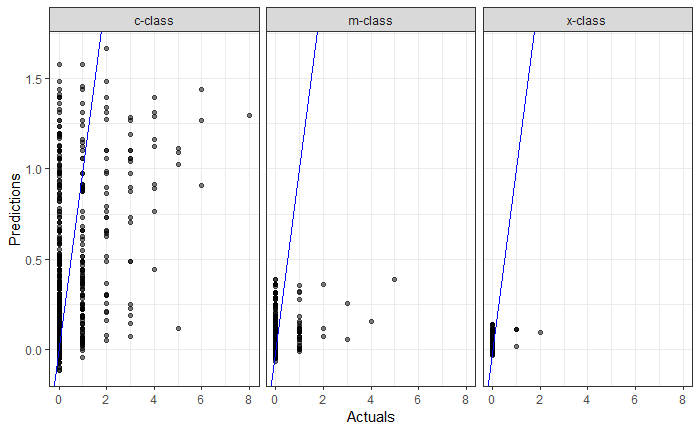

```r
p <- ggplot(py$data_plot, aes(y_actual, y_pred))  # reticulate
p <- p + geom_point(alpha = .5)
p <- p + geom_abline(color = "blue")
p <- p + facet_wrap(~ outcome)
p <- p + theme_bw() + xlab("Actuals") + ylab("Predictions")
p
```

### Shapley values

#### Custom prediction function

- This prediction function has the same format as the `iml` prediction function with the exception that two new arguments exist for the categorical and numerical features names.
- The input data is a Pandas DataFrame.

```python
def prediction_function(model, data, cat_feature_names, num_feature_names):
    data_x = copy.copy(data)
    data_x = pd.DataFrame(data_x)

    X_model_cat = data_x[cat_feature_names]
    X_model_num = data_x[num_feature_names]
    X_model_input = list(X_model_num)

    model_input_data = [[None] for _ in range(len(categorical_features))]
    for i in range(len(model_input_data)):
        model_input_data[i] = X_model_cat.iloc[:, i]
    model_input_data.append(X_model_num)
    return(pd.DataFrame(model.predict(model_input_data)))
```

#### A re-write of iml::Shapley()

- The function `shap_feature_effects()` below does the main Shapley value computation.
- It takes a Pandas DataFrame as input. The argument `explain_instance` below is the same as `x.interest` in the `iml` R function which takes one row of a Pandas DataFrame as input. For the `sample_size` argument, higher is better–100 is a reasonable starting value.

```python
def shap_feature_effects(data, explain_instance, sample_size = 100):

  # Coerce the DataFrames to numpy matrices for speed.
  data_x = data.values
  explain_instance_x = explain_instance.values

  n_features = data_x.shape[1]
  feature_names = data.columns.values
  n_rows = data_x.shape[0]

  # This list holds our final results
  data_feature_effects = [[None] for _ in range(sample_size)]
  # This list gets overwritten after each i loop.
  data_target_vs_comparison_shuffled_features = [[None] for _ in range(n_features)]

  for i in range(0, sample_size):
      # Shuffle the column indices, keeping all column indices.
      feature_indices_random = np.random.choice(np.arange(0, n_features), size = n_features, replace = False)

      # Select one row, or row index, from the input dataset.
      row_index_random = np.random.choice(np.arange(0, n_rows), size = 1, replace = False)

      # Shuffle the column order for the randomly selected row.
      random_instance = data_x[row_index_random, feature_indices_random].reshape(1, n_features)

      # For the target row that is selected, shuffle the columns to match our randomly selected and shuffled instance.
      target_instance = explain_instance_x[:, feature_indices_random]

      for j in range(0, n_features):
              # For each feature in the loop, find the position or index of the shuffled column.
              feature_index = np.where(feature_indices_random == j)[0][0]

              # Save the feature value for the target instance for the output dataframe.
              feature_value = target_instance[:, feature_index][0]

              # This is our target instance, shuffled.
              target_instance_with_feature = copy.copy(target_instance)

              # If the shuffled feature is not in the last column, replace columns (feature_index + 1):(n_features)
              # in the target instance with the same columns from our randomly selected instance.
              if feature_index < (n_features - 1):
                  target_instance_with_feature[(feature_index + 1):(n_features)] = random_instance[(feature_index + 1):(n_features)]

              # Now, we'll take our target instance with the (feature_index + 1):(n_features) shuffled columns
              # and replace our current target feature in this loop to get a comparison instance that only
              # differs with respect to the current target feature.
              target_instance_without_feature = copy.copy(target_instance_with_feature)
              target_instance_without_feature[:, feature_index] = random_instance[:, feature_index]

              # Re-order the datasets to match the data input. We'll also add a group identifier so that we can
              # calculate the marginal effect of each predictor with a group_by() function.
              target_instance_with_feature = target_instance_with_feature[:, np.argsort(feature_indices_random)]
              target_instance_without_feature = target_instance_without_feature[:, np.argsort(feature_indices_random)]

              # Create meta-data for the output. We need two of everything because the output of this j loop
              # is a 2 row dataframe that differs only with respect to the target feature in this loop.
              feature_group = np.array(['feature_static', 'feature_dynamic'])
              feature_name = np.repeat(feature_names[j], 2)
              feature_value = np.repeat(feature_value, 2)
              row_index = np.repeat(row_index_random, 2)

              meta_data = np.vstack([feature_group, feature_name, feature_value, row_index]).T
              data_target_instance = np.vstack([target_instance_with_feature, target_instance_without_feature])
              data_target_instance = np.hstack([data_target_instance, meta_data])

              # Creat the output dataframe.
              data_target_instance = pd.DataFrame(data_target_instance,
                  columns = feature_names.tolist() + ['feature_group', 'feature_name', 'feature_value', 'row_index'])
              # Save the output dataframe to our list.
              data_target_vs_comparison_shuffled_features[j] = data_target_instance

      data_feature_effects[i] = pd.concat(data_target_vs_comparison_shuffled_features, sort = False)
  data_feature_effects = pd.concat(data_feature_effects, sort = False)
  return(data_feature_effects)
```

- The second custom function, `shap_summary()`, is a helper function that organizes the results of `shap_feature_effects()` to be similar to `iml::Shapley()`.
- The `data_predicted` argument takes the output from `prediction_function()` and the `data_feature_effects` argument takes the output from `shap_feature_effects()`.

```python
def shap_summary(data_predicted, data_feature_effects):

    data_predicted = copy.copy(data_predicted)
    data_feature_effects = copy.copy(data_feature_effects)

    n_outcomes = data_predicted.shape[1]

    data_predicted['feature_group'] = data_feature_effects['feature_group'].values
    data_predicted['feature_name'] = data_feature_effects['feature_name'].values
    data_predicted['feature_value'] = data_feature_effects['feature_value'].values
    data_predicted['row_index'] = data_feature_effects['row_index'].values

    y_hat_with_feature = data_predicted.loc[data_predicted['feature_group'] == 'feature_static', :]
    y_hat_without_feature = data_predicted.loc[data_predicted['feature_group'] == 'feature_dynamic', :]
    y_hat_with_feature.reset_index(drop = True, inplace = True)
    y_hat_without_feature.reset_index(drop = True, inplace = True)

    y_hat_diff = y_hat_with_feature.iloc[:, range(n_outcomes)] - y_hat_without_feature.iloc[:, range(n_outcomes)]

    y_hat_diff['feature_name'] = y_hat_with_feature['feature_name']
    y_hat_diff['feature_value'] = y_hat_with_feature['feature_value']

    y_hat_diff = pd.melt(y_hat_diff, id_vars = ['feature_name', 'feature_value'], var_name = 'outcome', value_name = 'value')

    y_hat_diff['shap_mean'] = y_hat_diff.groupby(['feature_name', 'outcome'])['value'].transform(lambda x: np.mean(x))
    y_hat_diff['shap_variance'] = y_hat_diff.groupby(['feature_name', 'outcome'])['value'].transform(lambda x: np.var(x))
    y_hat_diff = y_hat_diff.drop_duplicates(['feature_name', 'outcome'])
    y_hat_diff.drop(['value'], axis = 1, inplace = True)
    y_hat_diff.reset_index(drop = True, inplace = True)

    return(y_hat_diff)
```

#### Compute Shapley values

- With our custom functions ready, let’s prepare the input dataset.
  - First, because we’re using a computationally intensive approach to compute Shapley values, we’ll filter our dataset to only explain the 201 instances with 1 or more positive counts across the 3 outcomes.
  - Next, we’ll drop the outcome columns from our dataset so that they won’t appear in our Shapley results table.
- Now we’ll loop through our filtered dataset, computing Shapley values for one instance at a time and saving the results table to a list.
- Similar to R, the the following code runs in ~3 minutes on an Intel i7 16GB laptop.

```python
data_shap = copy.copy(data)
# Filter to select instances with 1 or more positive outcomes.
data_shap = data_shap.loc[data_shap[outcome_names].sum(axis = 1) > 0, :]
data_shap = data_shap.drop(outcome_names, axis = 1)

start = timer()
shap_values = [[None] for _ in range(data_shap.shape[0])]
for i in range(len(shap_values)):
  data_feature_effects = shap_feature_effects(data = data_shap,
                                              explain_instance = data_shap.iloc[[i], :], sample_size = 100)
  data_predicted = prediction_function(model, data_feature_effects, categorical_features, numeric_features)
  shap_values[i] = shap_summary(data_predicted, data_feature_effects)
  shap_values[i]['sample_num'] = i
end = timer()
data_shap_values = pd.concat(shap_values, sort = False)
print(end - start)
```

#### Plot feature effects

- Each instance in the dataset gets a series of Shapley values which explain how each feature affected the predictions for *each outcome*. To think about it another way, each instance gets 3 feature effect profiles. These local, instance-level explanations of how the model behaves are the main selling point of Shapley values, but we can also aggregate the individual results to get measures of global feature importance across all instances.
- **Global feature importance:** Let’s plot the Shapley values for our (a) set of categorical predictors and (b) numeric predictor(s). We’ll plot the Shapley values against the values of the features in the original dataset to obtain a plot similar to a [partial dependence plot](https://christophm.github.io/interpretable-ml-book/pdp.html). This plot will help us see how changing the value of a feature tends to change model predictions.
- **Interpretation:**
  - In the plots below, a Shapley value of 0 on the vertical axis represents the average predicted number of solar flares for each outcome from our Keras model. These average predictions are as follows:
    - c-class = 0.784 solar flares
    - m-class = 0.055 solar flares
    - x-class = 0.056 solar flares
- **Findings:**
  - It’s important to reiterate that because we’re using a sampling technique to compute the Shapley values, the results will change from one run to the next.
  - The categorical predictors `largest_spot_size`, `mod_zurich_class`, have, depending on the level of the categorical feature, strong influences on the model’s predictions. Looking at `largest_spot_size`, a value of 4 increases c-class model predicted solar flares by about 0.4 solar flares on average.

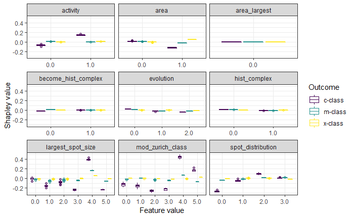

```r
# Use reticulate's py$... to transfer an object from the Python to the R environment.
data_shap_values_python <- py$data_shap_values
data_shap_values_python$outcome <- unlist(data_shap_values_python$outcome)
data_shap_values_python$outcome <- factor(data_shap_values_python$outcome, labels = outcome_names)

data_shap_cat <- data_shap_values_python[data_shap_values_python$feature_name %in% categorical_features, ]
data_shap_num <- data_shap_values_python[data_shap_values_python$feature_name %in% numeric_features, ]

p <- ggplot(data_shap_cat, aes(x = as.factor(feature_value), y = shap_mean, color = outcome))
p <- p + geom_boxplot(alpha = .50)
p <- p + scale_colour_viridis_d()
p <- p + facet_wrap(~ feature_name, scales = "free_x")
p <- p + theme_bw() + xlab("Feature value") + ylab("Shapley value") + labs(color = "Outcome")
p
```

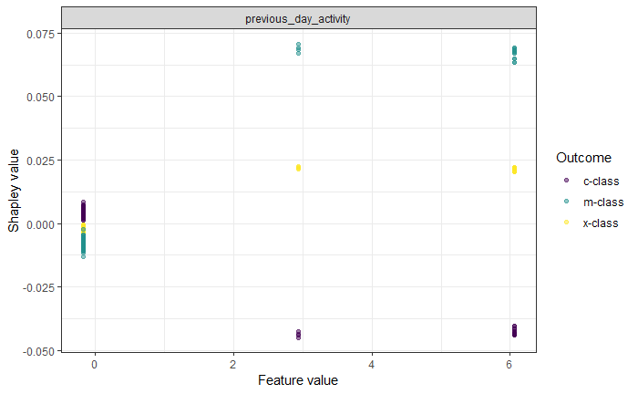

```r
p <- ggplot(data_shap_num, aes(x = round(as.numeric(feature_value), 2), y = shap_mean,
                               color = outcome))
p <- p + geom_point(alpha = .50)
p <- p + scale_colour_viridis_d()
p <- p + facet_wrap(~ feature_name)
p <- p + theme_bw() + xlab("Feature value") + ylab("Shapley value") + labs(color = "Outcome")
p
```

- **Local feature importance:** Let’s plot the Shapley values for a single instance in the dataset. This plot shows an individualized feature effect profile and would be unique for each instance in our dataset.
- **Interpretation:**
  - For this instance, the red bars represent a feature that decreased the model’s predictions relative to the average prediction for each outcome (the average prediction has been centered at 0). Blue bars represent a feature that increased the predicted number of solar flares.
  - If our sample size was large enough (or if we were using [an exact method for calculating Shapley values](https://arxiv.org/abs/1802.03888)), for each outcome we could simply sum the positive and negative Shapley values for each feature and add the result to the average prediction for each outcome and arrive at the same predicted value that we get from our `predict()` function.

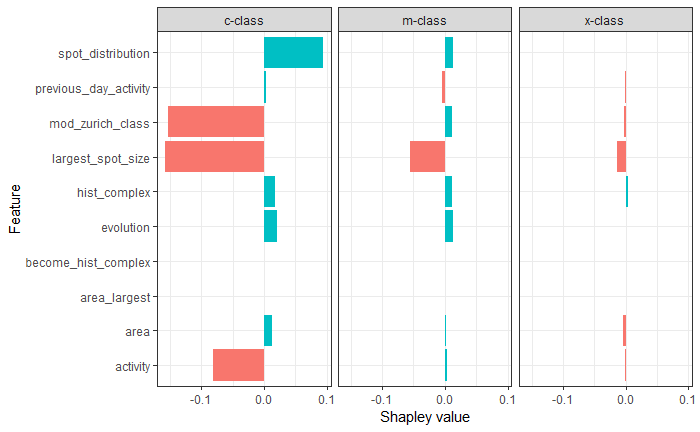

```r
data_plot <- data_shap_values_python
data_plot <- dplyr::filter(data_plot, sample_num == 1)

data_plot$bar_color <- ifelse(data_plot$shap_mean >= 0, "increase", "decrease")

p <- ggplot(data_plot, aes(x = feature_name, y = shap_mean, fill = bar_color, group = sample_num))
p <- p + geom_bar(stat = "identity", show.legend = FALSE)
p <- p + facet_wrap(~ outcome)
p <- p + theme_bw() + coord_flip() + xlab("Feature") + ylab("Shapley value")
p
```

## Comparing Results

Before we go we’ll take a look at our Shapley value plots of global feature importance for our categorical predictors to see where we are. We built the same model in Keras in each langauge and hopefully our re-write of `iml::Shapley()` in Python was faithful. So any differences that we see between feature effects should be down to the stochastic nature of our Shapley value computations.

We could be more formal in our comparison here, but a quick glance at the plots below shows that **our Shapley results are similar in magnitude and pattern**. This is good news. Interestingly, the effects for certain levels of `largest_spot_size` and `mod_zurich_class` are similar in size but flipped in direction. This feature effect reversal is likely the result of our sampling-based Shapley calculations and differnces in seeds between R and Python. Randomness aside, a useful next step in comparing results would be to look at the feature embedding maps for each model to see if they are, in fact, the same.

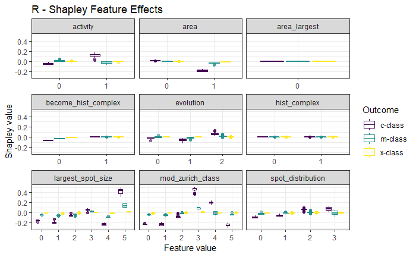

```r
# R
data_shap_values$feature_value <- substr(data_shap_values$feature.value,
                                         stringr::str_locate(data_shap_values$feature.value, "=")[, 1] + 1,
                                         nchar(data_shap_values$feature.value))
data_shap_values$feature_value <- as.numeric(data_shap_values$feature_value)
data_shap_values$outcome <- factor(data_shap_values$class, labels = outcome_names)

data_shap_cat <- data_shap_values[data_shap_values$feature %in% categorical_features, ]
data_shap_num <- data_shap_values[data_shap_values$feature %in% numeric_features, ]

p <- ggplot(data_shap_cat, aes(x = factor(feature_value), y = phi, color = outcome))
p <- p + geom_boxplot(alpha = .50)
p <- p + scale_colour_viridis_d()
p <- p + facet_wrap(~ feature, scales = "free_x")
p <- p + theme_bw() + xlab("Feature value") + ylab("Shapley value") + labs(color = "Outcome")
p <- p + ggtitle("R - Shapley Feature Effects")
p
```

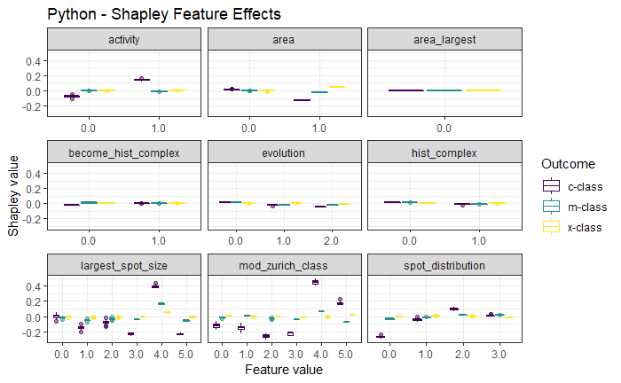

```r
# Python
# Use reticulate's py$... to transfer an object from the Python to the R environment.
data_shap_values_python <- py$data_shap_values
data_shap_values_python$outcome <- unlist(data_shap_values_python$outcome)
data_shap_values_python$outcome <- factor(data_shap_values_python$outcome, labels = outcome_names)

data_shap_cat <- data_shap_values_python[data_shap_values_python$feature_name %in% categorical_features, ]

p <- ggplot(data_shap_cat, aes(x = as.factor(feature_value), y = shap_mean, color = outcome))
p <- p + geom_boxplot(alpha = .50)
p <- p + scale_colour_viridis_d()
p <- p + facet_wrap(~ feature_name, scales = "free_x")
p <- p + theme_bw() + xlab("Feature value") + ylab("Shapley value") + labs(color = "Outcome")
p <- p + ggtitle("Python - Shapley Feature Effects")
p
```

## Final Thoughts

In this tutorial we stepped through an applied multi-input, multi-output machine learning problem in both R and Python and obtained Shapley values which were used to summarize the effects of the models’ features across multiple outcomes. The re-write of the R `iml` package’s Shapley function into Python, while certainly not production-worthy code, appears to be working as intended. Hopefully, you can use this tutorial as a template for similar problems in your data science language of choice.

Dua, D. and Karra Taniskidou, E. (2017). UCI Machine Learning Repository [http://archive.ics.uci.edu/ml]. Irvine, CA: University of California, School of Information and Computer Science.